# Lab 5 (solution)

dplyr

2022-02-09

**dplyr**

## Load library packages

```r
library(tidyverse)
library(gapminder)
```

## UN data, A world of information

data.un.org.

## Data

The data are [an excerpt from the Gapminder dataset](https://github.com/jennybc/gapminder)

```r
glimpse(gapminder)
```

```
## Rows: 1,704
## Columns: 6
## $ country   <fct> Afghanistan, Afghanistan, Afghanistan, Afghanistan, Afghani…
## $ continent <fct> Asia, Asia, Asia, Asia, Asia, Asia, Asia, Asia, Asia, Asia,…
## $ year      <int> 1952, 1957, 1962, 1967, 1972, 1977, 1982, 1987, 1992, 1997,…
## $ lifeExp   <dbl> 28.801, 30.332, 31.997, 34.020, 36.088, 38.438, 39.854, 40.…
## $ pop       <int> 8425333, 9240934, 10267083, 11537966, 13079460, 14880372, 1…
## $ gdpPercap <dbl> 779.4453, 820.8530, 853.1007, 836.1971, 739.9811, 786.1134,…
```

## subset data

- select
- filter
- arrange

### select

Subset the gapminder tibble (data frame) by columns. Display only the `year` and the `pop` columns.

The infix operator `%>%` is not part of base R, but is in fact defined by the package `magrittr` and is heavily used by `dplyr`. What the function does is to pass the left hand side of the operator to the first argument of the right hand side of the operator.

```r
gapminder %>%
  select(year, pop)
```

| year | pop |
| --- | --- |
| 1952 | 8425333 |
| 1957 | 9240934 |
| 1962 | 10267083 |
| 1967 | 11537966 |
| 1972 | 13079460 |
| 1977 | 14880372 |
| 1982 | 12881816 |
| 1987 | 13867957 |
| 1992 | 16317921 |
| 1997 | 22227415 |

[output cut: 1694 more lines]

```r
gapminder %>%
  select(2:4, 6)
```

| continent | year | lifeExp | gdpPercap |
| --- | --- | --- | --- |
| Asia | 1952 | 28.80100 | 779.4453 |
| Asia | 1957 | 30.33200 | 820.8530 |
| Asia | 1962 | 31.99700 | 853.1007 |
| Asia | 1967 | 34.02000 | 836.1971 |
| Asia | 1972 | 36.08800 | 739.9811 |
| Asia | 1977 | 38.43800 | 786.1134 |
| Asia | 1982 | 39.85400 | 978.0114 |
| Asia | 1987 | 40.82200 | 852.3959 |
| Asia | 1992 | 41.67400 | 649.3414 |
| Asia | 1997 | 41.76300 | 635.3414 |

[output cut: 1694 more lines]

### filter

Subset the gapminder tibble, keeping data for the year 1987

```r
gapminder %>%
  filter(year==1987)
```

| country | continent | year | lifeExp | pop | gdpPercap |
| --- | --- | --- | --- | --- | --- |
| Afghanistan | Asia | 1987 | 40.822 | 13867957 | 852.3959 |
| Albania | Europe | 1987 | 72.000 | 3075321 | 3738.9327 |
| Algeria | Africa | 1987 | 65.799 | 23254956 | 5681.3585 |
| Angola | Africa | 1987 | 39.906 | 7874230 | 2430.2083 |
| Argentina | Americas | 1987 | 70.774 | 31620918 | 9139.6714 |
| Australia | Oceania | 1987 | 76.320 | 16257249 | 21888.8890 |
| Austria | Europe | 1987 | 74.940 | 7578903 | 23687.8261 |
| Bahrain | Asia | 1987 | 70.750 | 454612 | 18524.0241 |
| Bangladesh | Asia | 1987 | 52.819 | 103764241 | 751.9794 |
| Belgium | Europe | 1987 | 75.350 | 9870200 | 22525.5631 |

[output cut: 132 more lines]

```r
gapminder %>%
  filter(year==1987) %>%
  filter(continent=="Oceania")
```

| country | continent | year | lifeExp | pop | gdpPercap |
| --- | --- | --- | --- | --- | --- |
| Australia | Oceania | 1987 | 76.32 | 16257249 | 21888.89 |
| New Zealand | Oceania | 1987 | 74.32 | 3317166 | 19007.19 |

### arrange

1. sort by populations
2. sort continent in reverse alphabetical order
   1. subsort in reverse chronological by year

```r
gapminder %>%
  arrange(pop)
```

| country | continent | year | lifeExp | pop | gdpPercap |
| --- | --- | --- | --- | --- | --- |
| Sao Tome and Principe | Africa | 1952 | 46.47100 | 60011 | 879.5836 |
| Sao Tome and Principe | Africa | 1957 | 48.94500 | 61325 | 860.7369 |
| Djibouti | Africa | 1952 | 34.81200 | 63149 | 2669.5295 |
| Sao Tome and Principe | Africa | 1962 | 51.89300 | 65345 | 1071.5511 |
| Sao Tome and Principe | Africa | 1967 | 54.42500 | 70787 | 1384.8406 |
| Djibouti | Africa | 1957 | 37.32800 | 71851 | 2864.9691 |
| Sao Tome and Principe | Africa | 1972 | 56.48000 | 76595 | 1532.9853 |
| Sao Tome and Principe | Africa | 1977 | 58.55000 | 86796 | 1737.5617 |
| Djibouti | Africa | 1962 | 39.69300 | 89898 | 3020.9893 |
| Sao Tome and Principe | Africa | 1982 | 60.35100 | 98593 | 1890.2181 |

[output cut: 1694 more lines]

```r
sorted_gap <-gapminder %>%
  arrange(desc(continent), desc(year)) %>%
  select(country, year, pop)

sorted_gap
```

| country | year | pop |
| --- | --- | --- |
| Australia | 2007 | 20434176 |
| New Zealand | 2007 | 4115771 |
| Australia | 2002 | 19546792 |
| New Zealand | 2002 | 3908037 |
| Australia | 1997 | 18565243 |
| New Zealand | 1997 | 3676187 |
| Australia | 1992 | 17481977 |
| New Zealand | 1992 | 3437674 |
| Australia | 1987 | 16257249 |
| New Zealand | 1987 | 3317166 |

[output cut: 1694 more lines]

```r
gapminder
```

| country | continent | year | lifeExp | pop | gdpPercap |
| --- | --- | --- | --- | --- | --- |
| Afghanistan | Asia | 1952 | 28.80100 | 8425333 | 779.4453 |
| Afghanistan | Asia | 1957 | 30.33200 | 9240934 | 820.8530 |
| Afghanistan | Asia | 1962 | 31.99700 | 10267083 | 853.1007 |
| Afghanistan | Asia | 1967 | 34.02000 | 11537966 | 836.1971 |
| Afghanistan | Asia | 1972 | 36.08800 | 13079460 | 739.9811 |
| Afghanistan | Asia | 1977 | 38.43800 | 14880372 | 786.1134 |
| Afghanistan | Asia | 1982 | 39.85400 | 12881816 | 978.0114 |
| Afghanistan | Asia | 1987 | 40.82200 | 13867957 | 852.3959 |
| Afghanistan | Asia | 1992 | 41.67400 | 16317921 | 649.3414 |
| Afghanistan | Asia | 1997 | 41.76300 | 22227415 | 635.3414 |

[output cut: 1694 more lines]

## Manipulate data

- mutate
- count
- summarize
- group_by

### mutate

Create a new variable. Make a new variable called “double_life” by multipling `lifeExp` by 2.

```r
gapminder %>%
  mutate(double_life= lifeExp*2)
```

| country | continent | year | lifeExp | pop | gdpPercap | double_life |
| --- | --- | --- | --- | --- | --- | --- |
| Afghanistan | Asia | 1952 | 28.80100 | 8425333 | 779.4453 | 57.60200 |
| Afghanistan | Asia | 1957 | 30.33200 | 9240934 | 820.8530 | 60.66400 |
| Afghanistan | Asia | 1962 | 31.99700 | 10267083 | 853.1007 | 63.99400 |
| Afghanistan | Asia | 1967 | 34.02000 | 11537966 | 836.1971 | 68.04000 |
| Afghanistan | Asia | 1972 | 36.08800 | 13079460 | 739.9811 | 72.17600 |
| Afghanistan | Asia | 1977 | 38.43800 | 14880372 | 786.1134 | 76.87600 |
| Afghanistan | Asia | 1982 | 39.85400 | 12881816 | 978.0114 | 79.70800 |
| Afghanistan | Asia | 1987 | 40.82200 | 13867957 | 852.3959 | 81.64400 |
| Afghanistan | Asia | 1992 | 41.67400 | 16317921 | 649.3414 | 83.34800 |
| Afghanistan | Asia | 1997 | 41.76300 | 22227415 | 635.3414 | 83.52600 |

[output cut: 1694 more lines]

### count

How many observations exist for each country within the data set.

```r
gapminder %>%
   count(country)
```

|  | country | n |
| --- | --- | --- |
| 1 | Afghanistan | 12 |
| 2 | Albania | 12 |
| 3 | Algeria | 12 |
| 4 | Angola | 12 |
| 5 | Argentina | 12 |
| 6 | Australia | 12 |
| 7 | Austria | 12 |
| 8 | Bahrain | 12 |
| 9 | Bangladesh | 12 |
| 10 | Belgium | 12 |

[output cut: 132 more lines]

#### distinct

Sometimes you just want to know the values within a variable…

List the `distinct` values within the `continent` column

```r
gapminder %>%
  distinct(continent)
```

| continent |
| --- |
| Asia |
| Europe |
| Africa |
| Americas |
| Oceania |

### summarize

Calculate the total of a single column. In this case `sum()` all the values in the `pop` column.

```r
sum(5, 7, 10)
```

```
## [1] 22
```

```r
gapminder %>%
  summarize(total_pop=sum(pop))
```

| total_pop |
| --- |
| 50440465801 |

Of course, it makes no sense to total that column but now you know how to get column totals. Generally we summarize subtotals using `group_by` along with summarize. group the observations by `year` and create subtotals with the `sum()` function. `comman()`: Comma Formatter: Format Number With Commas Separating Thousands.

```r
gapminder %>%
   group_by(year) %>%
   summarize(total_pop=scales::comma(sum(pop)))
```

|  | year | total_pop |
| --- | --- | --- |
| 1 | 1952 | 2,406,957,150 |
| 2 | 1957 | 2,664,404,580 |
| 3 | 1962 | 2,899,782,974 |
| 4 | 1967 | 3,217,478,384 |
| 5 | 1972 | 3,576,977,158 |
| 6 | 1977 | 3,930,045,807 |
| 7 | 1982 | 4,289,436,840 |
| 8 | 1987 | 4,691,477,418 |
| 9 | 1992 | 5,110,710,260 |
| 10 | 1997 | 5,515,204,472 |

[output cut: 2 more lines]

Calculate the total and the mean population by year

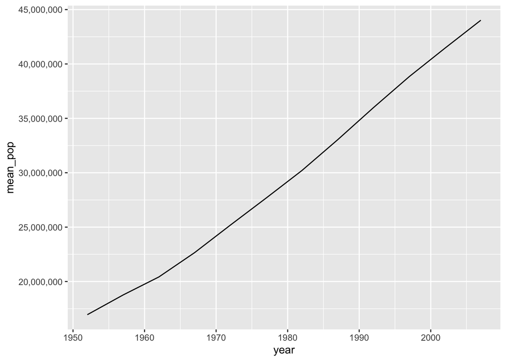

```r
gapminder %>%
   group_by(year) %>%
   summarize(total_pop=scales::comma(sum(pop)),mean_pop=mean(pop)) %>%
  ggplot(aes(x = year, y = mean_pop)) +
    geom_line() +
   scale_y_continuous(labels = scales::comma)
```